# Hogan_popgen

# Introduction

This is an exploratory analysis of the population structure of the NPRB Hogan Bay 2013-2016 genotype data, post-QA. Here we will:

- Read in all post-QA project genotypes
- Create a *genepop* file to read back in with *adegenet*
- Explore genetic structure
  - Among brood lines (even/odd)
  - Among years
  - Among hatchery/wild (note different hatcheries have different brood sources)
  - Between sexes
- Export genotypes as a *Genepop* file to feed in to *genepop2franz.GCL.r*

# Create genepop

Create a *genepop* using `gcl2Genepop.GCL`, individuals are named by *SillySource*.

```r
gcl2Genepop.GCL(sillyvec = c("PHOGAN14n", "PHOGAN14h", "PHOGAN16"),
                loci = loci,
                path = "../Genepop/hogan_even_postQA.gen",
                VialNums = TRUE,
                usat = FALSE)
```

Note that I created separate genepop files for each lineage in addition to one for the complete dataset so I could run separate PCAs by lineage.

```r
#When we pooled PHOGAN 13 and 14, the FK_FISH_ID column was converted from numeric to character. However, it remained numeric for PHOGAN 15 and 16. Its structure needs to be uniform across tables to allow for combining.
PHOGAN15.gcl$attributes <- PHOGAN15.gcl$attributes %>%
  mutate(FK_FISH_ID = as.character(FK_FISH_ID))
PHOGAN16.gcl$attributes <- PHOGAN16.gcl$attributes %>%
  mutate(FK_FISH_ID = as.character(FK_FISH_ID))
HOGAN_attributes_tibble <- dplyr::bind_rows(PHOGAN13n.gcl$attributes, PHOGAN13h.gcl$attributes, PHOGAN14n.gcl$attributes, PHOGAN14h.gcl$attributes, PHOGAN15.gcl$attributes, PHOGAN16.gcl$attributes) %>%
  mutate(Lineage = case_when(SILLY_CODE %in% c("PHOGAN13", "PHOGAN15") ~ "ODD",
                             SILLY_CODE %in% c("PHOGAN14", "PHOGAN16") ~ "EVEN"))
write_csv(HOGAN_attributes_tibble, "../Attributes table/HOGAN_attributes_tibble.csv")
HOGAN_attributes_odd_tibble <- dplyr::bind_rows(PHOGAN13n.gcl$attributes, PHOGAN13h.gcl$attributes, PHOGAN15.gcl$attributes)
HOGAN_attributes_even_tibble <- dplyr::bind_rows(PHOGAN14n.gcl$attributes, PHOGAN14h.gcl$attributes, PHOGAN16.gcl$attributes)
```

# Analysis in *adegenet*

```r
Hogan_even <- read.genepop(file="v:/Analysis/5_Coastwide/Multispecies/Alaska Hatchery Research Program/PWS Pink/Genepop/hogan_even_postQA.gen")
```

```
 Converting data from a Genepop .gen file to a genind object...


File description:  GENEPOP input format

...done.
```

## Inbreeding Estimates

Here we will: 1. Create separate genind files for each year and origin. 2. Estimate and plot inbreeding (F). 3. Calculate and plot mean F across individuals.

```r
#compute means for all individuals
Fmean_13n <- sapply(Fs_13n, mean)
Fmean_13h <- sapply(Fs_13h, mean)
Fmean_14n <- sapply(Fs_14n, mean)
Fmean_14h <- sapply(Fs_14h, mean)
Fmean_15 <- sapply(Fs_15, mean)
Fmean_16 <- sapply(Fs_16, mean)
par(mfrow=c(3,3))
hist(Fmean_13n, col="orange", xlab="Mean value of F", main="2013 natural")
hist(Fmean_13h, col="orange", xlab="Mean value of F", main="2013 hatchery")
```

```r
hist(Fmean_14n, col="Orange", xlab="Mean value of F", main="2014 natural")
hist(Fmean_14h, col="orange", xlab="Mean value of F", main="2014 hatchery")
```

[figure not shown]

```r
hist(Fmean_15, col="orange", xlab="Mean value of F", main="2015")
hist(Fmean_16, col="orange", xlab="Mean value of F", main="2016")
```

## Fst

Here we will: 1. Calculate Fst, Fit, and Fis. 2. Calculate PW Fst across year*origin.

```r
fstat(Hogan)
```

```
             pop          Ind
Total 0.05191092  0.043963001
pop   0.00000000 -0.008383096
```

This is a table of global F statistics (across all individuals in the dataset). Fst=pop/total=0.05 Fit=ind/total=0.04 Fis=ind/pop=0

```r
PW_Fst_Hogan <- pairwise.fst(Hogan)
PW_Fst_Hogan
```

```
             1            2            3            4            5
2 0.0008203227
3 0.0353466778 0.0320819445
4 0.0352826785 0.0357628929 0.0009296721
5 0.0002857582 0.0003171632 0.0131281686 0.0214887247
6 0.0103150576 0.0132234243 0.0001284349 0.0001379334 0.0307654839
```

These are pairwise Fst values among populations and origins. Note that I’ve turned this into an Excel heatmap (“v:/Analysis/5_Coastwide/Multispecies/Alaska Hatchery Research Program/PWS Pink/Genepop”), which is much easier to interpret because it includes population names. Differentiation is evident across, but not within, lineages.

## Principal Components Analysis

The purpose of the PCAs is to visualize the distribution of variation across the dataset (and subsets of the data) and calculate the extent to which the following variables contribute to that variation: year, lineage, origin, hatchery, and sex.

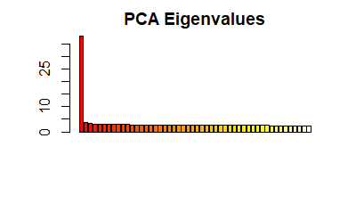

```r
pca1
```

```
Duality diagramm
class: pca dudi
$call: dudi.pca(df = Hogan_imputed, center = FALSE, scale = FALSE, scannf = FALSE,
    nf = 3)

$nf: 3 axis-components saved
$rank: 366
eigen values: 38.18 3.872 3.453 3.122 3.098 ...
  vector length mode    content
1 $cw    670    numeric column weights
2 $lw    7367   numeric row weights
3 $eig   366    numeric eigen values

  data.frame nrow ncol content
1 $tab       7367 670  modified array
2 $li        7367 3    row coordinates
3 $l1        7367 3    row normed scores
4 $co        670  3    column coordinates
5 $c1        670  3    column normed scores
other elements: cent norm
```

The output object is a list containing: 1) $eig (eigenvalues), 2) $li (PC’s), 3) $c1 (allele loadings).

```r
s.class(pca1$li, pop(Hogan))
title("PCA\naxes 1-2")
```

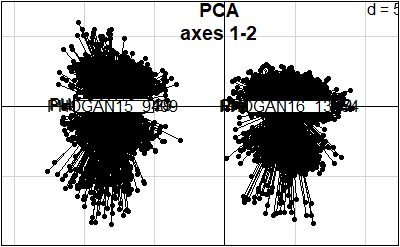

```r
add.scatter.eig(pca1$eig[1:20], 3, 1, 2)
```

Axis 1 clearly separates the two lineages. Odd is on the left and even is on the right.

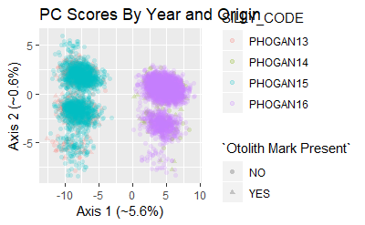

```r
par(mfrow=c(1,3))
ggplot(Scores_Attributes, aes(x=Axis1, y=Axis2, shape=`Otolith Mark Present`, color=SILLY_CODE)) +
  geom_point(alpha=0.2) +
  labs(title="PC Scores By Year and Origin", x="Axis 1 (~5.6%)", y="Axis 2 (~0.6%)")
```

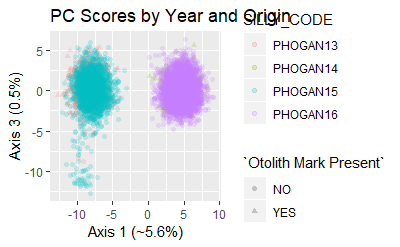

```r
ggplot(Scores_Attributes, aes(x=Axis1, y=Axis3, shape=`Otolith Mark Present`, color=SILLY_CODE)) +
  geom_point(alpha=0.2) +
  labs(title="PC Scores by Year and Origin", x="Axis 1 (~5.6%)", y="Axis 3 (0.5%)")
```

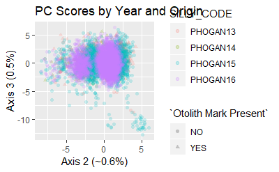

```r
ggplot(Scores_Attributes, aes(x=Axis2, y=Axis3, shape=`Otolith Mark Present`, color=SILLY_CODE)) +
  geom_point(alpha=0.2) +
  labs(title="PC Scores by Year and Origin", x= "Axis 2 (~0.6%)", y="Axis 3 (0.5%)")
```

Axis labels provide the percent variation explained. Note that the axes do not explain much of the overall variation. This supports that there’s little overall population structure.

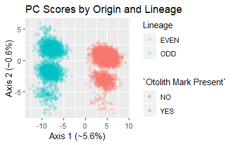

```r
ggplot(Scores_Attributes, aes(x=Axis1, y=Axis2, shape=`Otolith Mark Present`, color=Lineage)) +
  geom_point(alpha=0.2) +
  labs(title = "PC Scores by Origin and Lineage", x="Axis 1 (~5.6%)", y="Axis 2 (~0.6%)")
```

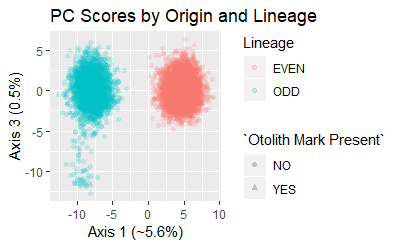

```r
ggplot(Scores_Attributes, aes(x=Axis1, y=Axis3, shape=`Otolith Mark Present`, color=Lineage)) +
  geom_point(alpha=0.2) +
  labs(title = "PC Scores by Origin and Lineage", x="Axis 1 (~5.6%)", y="Axis 3 (0.5%)")
```

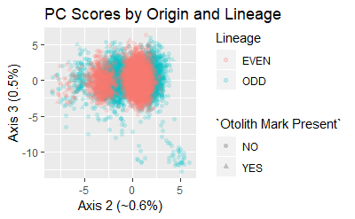

```r
ggplot(Scores_Attributes, aes(x=Axis2, y=Axis3, shape=`Otolith Mark Present`, color=Lineage)) +
  geom_point(alpha=0.2) +
  labs(title = "PC Scores by Origin and Lineage",  x= "Axis 2 (~0.6%)", y="Axis 3 (0.5%)")
```

These are PC plots of the full dataset with individuals categorized by origin and lineage. Axis 1 separates the lineages. Axis 2 shows separation within lineages. Axis 3 shows separation of some natural origin fish from the odd lineage (natural strays?). The plot of Axis2 versus Axis3 shows evidence of multimodality within lineages, suggesting that the data are not normally distributed. We had considered plotting mean scores by lineage, year, origin, and sex, but given this non-normality, the approach seemed inappropriate and potentially misleading.

Update: After speaking with Chris and Wei, we determined that these clusters are likely artefacts and represent genotype frequencies. This is a limitation of using categorical data as input in a PCA. This is corroborated by (https://privefl.github.io/bigsnpr/articles/how-to-PCA.html) - Scroll down to the explanation of plots of axes 3 and 4.

Let’s examine our loadings.

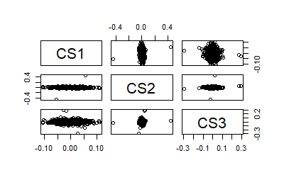

```r
plot(pca1$c1)
```

```r
max_loading <- max(pca1$c1)
max_loading
```

```
[1] 0.4445275
```

```r
min_loading <- min(pca1$c1)
min_loading
```

```
[1] -0.4445275
```

```r
range_loading <- range(pca1$c1)
range_loading
```

```
[1] -0.4445275  0.4445275
```

Similar to the example cited above, it appears that the banding we observed in axes 2 and 3 may be representing variation at just a couple of loci.

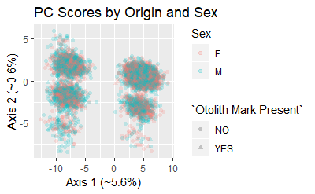

```r
ggplot(Scores_Attributes, aes(x=Axis1, y=Axis2, shape=`Otolith Mark Present`, color=Sex)) +
  geom_point(alpha=0.2) +
  labs(title = "PC Scores by Origin and Sex", x="Axis 1 (~5.6%)", y="Axis 2 (~0.6%)")
```

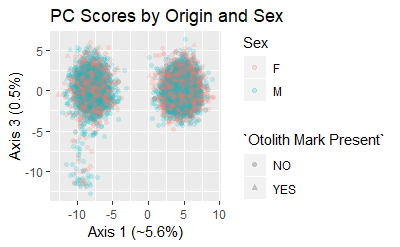

```r
ggplot(Scores_Attributes, aes(x=Axis1, y=Axis3, shape=`Otolith Mark Present`, color=Sex)) +
  geom_point(alpha=0.2) +
  labs(title = "PC Scores by Origin and Sex", x="Axis 1 (~5.6%)", y="Axis 3 (0.5%)")
```

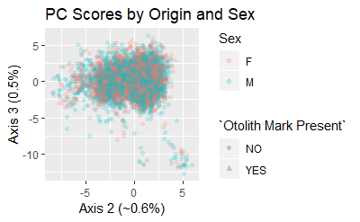

```r
ggplot(Scores_Attributes, aes(x=Axis2, y=Axis3, shape=`Otolith Mark Present`, color=Sex)) +
  geom_point(alpha=0.2) +
  labs(title = "PC Scores by Origin and Sex", x= "Axis 2 (~0.6%)", y="Axis 3 (0.5%)")
```

These are plots of the full dataset with individuals categorized by origin and sex. Overall, hatchery and natural origin fish and males and females appear admixed. The clustering we see along axis two does not seem to be due to sex or origin differences. The individuals that separate out along axis 3 appear to be a combination of males and females, but qualitatively may be male-biased.

These plots are consistently showing that axis 1 separates the two lineages, which is what we expect. However, we do see some apparent clustering along axes 2 and 3. We used anovas to determine which variables are driving the variation in these scores.

```r
aov_PC2 <- aov(Scores_Attributes$Axis2 ~ Scores_Attributes$SILLY_CODE*Scores_Attributes$Sex*Scores_Attributes$`Otolith Mark Present`)
aov_PC2
```

```
Call:
   aov(formula = Scores_Attributes$Axis2 ~ Scores_Attributes$SILLY_CODE *
    Scores_Attributes$Sex * Scores_Attributes$`Otolith Mark Present`)

Terms:
                Scores_Attributes$SILLY_CODE Scores_Attributes$Sex Scores_Attributes$`Otolith Mark Present`
Sum of Squares                        10.946                 0.942                                    1.052
Deg. of Freedom                            3                     1                                        1
                Scores_Attributes$SILLY_CODE:Scores_Attributes$Sex
Sum of Squares                                              17.818
Deg. of Freedom                                                  3
                Scores_Attributes$SILLY_CODE:Scores_Attributes$`Otolith Mark Present`
Sum of Squares                                                                  0.962
Deg. of Freedom                                                                     1
                Scores_Attributes$Sex:Scores_Attributes$`Otolith Mark Present`
Sum of Squares                                                          34.906
Deg. of Freedom                                                              1
                Scores_Attributes$SILLY_CODE:Scores_Attributes$Sex:Scores_Attributes$`Otolith Mark Present` Residuals
Sum of Squares                                                                                        2.753 28457.670
Deg. of Freedom                                                                                           1      7355

Residual standard error: 1.967018
4 out of 16 effects not estimable
Estimated effects may be unbalanced
```

```r
summary(aov_PC2)
```

```
                                                                                              Df Sum Sq Mean Sq F value  Pr(>F)
Scores_Attributes$SILLY_CODE                                                                   3     11    3.65   0.943 0.41881
Scores_Attributes$Sex                                                                          1      1    0.94   0.243 0.62174
Scores_Attributes$`Otolith Mark Present`                                                       1      1    1.05   0.272 0.60206
Scores_Attributes$SILLY_CODE:Scores_Attributes$Sex                                             3     18    5.94   1.535 0.20320
Scores_Attributes$SILLY_CODE:Scores_Attributes$`Otolith Mark Present`                          1      1    0.96   0.249 0.61805
Scores_Attributes$Sex:Scores_Attributes$`Otolith Mark Present`                                 1     35   34.91   9.022 0.00268
Scores_Attributes$SILLY_CODE:Scores_Attributes$Sex:Scores_Attributes$`Otolith Mark Present`    1      3    2.75   0.711 0.39900
Residuals                                                                                   7355  28458    3.87

Scores_Attributes$SILLY_CODE
Scores_Attributes$Sex
Scores_Attributes$`Otolith Mark Present`
Scores_Attributes$SILLY_CODE:Scores_Attributes$Sex
Scores_Attributes$SILLY_CODE:Scores_Attributes$`Otolith Mark Present`
Scores_Attributes$Sex:Scores_Attributes$`Otolith Mark Present`                              **
Scores_Attributes$SILLY_CODE:Scores_Attributes$Sex:Scores_Attributes$`Otolith Mark Present`
Residuals
---
Signif. codes:  0 ‘***’ 0.001 ‘**’ 0.01 ‘*’ 0.05 ‘.’ 0.1 ‘ ’ 1
```

This is an anova for Axis 2 scores. There is a significant interaction between sex and origin (p=0.003).

```r
aov_PC3 <- aov(Scores_Attributes$Axis3 ~ Scores_Attributes$SILLY_CODE*Scores_Attributes$Sex*Scores_Attributes$`Otolith Mark Present`)
aov_PC3
```

```
Call:
   aov(formula = Scores_Attributes$Axis3 ~ Scores_Attributes$SILLY_CODE *
    Scores_Attributes$Sex * Scores_Attributes$`Otolith Mark Present`)

Terms:
                Scores_Attributes$SILLY_CODE Scores_Attributes$Sex Scores_Attributes$`Otolith Mark Present`
Sum of Squares                       188.196                16.414                                    9.570
Deg. of Freedom                            3                     1                                        1
                Scores_Attributes$SILLY_CODE:Scores_Attributes$Sex
Sum of Squares                                              11.384
Deg. of Freedom                                                  3
                Scores_Attributes$SILLY_CODE:Scores_Attributes$`Otolith Mark Present`
Sum of Squares                                                                  0.027
Deg. of Freedom                                                                     1
                Scores_Attributes$Sex:Scores_Attributes$`Otolith Mark Present`
Sum of Squares                                                           0.165
Deg. of Freedom                                                              1
                Scores_Attributes$SILLY_CODE:Scores_Attributes$Sex:Scores_Attributes$`Otolith Mark Present` Residuals
Sum of Squares                                                                                        2.280 25207.542
Deg. of Freedom                                                                                           1      7355

Residual standard error: 1.851288
4 out of 16 effects not estimable
Estimated effects may be unbalanced
```

```r
summary(aov_PC3)
```

```
                                                                                              Df Sum Sq Mean Sq F value   Pr(>F)
Scores_Attributes$SILLY_CODE                                                                   3    188   62.73  18.304 7.91e-12
Scores_Attributes$Sex                                                                          1     16   16.41   4.789   0.0287
Scores_Attributes$`Otolith Mark Present`                                                       1     10    9.57   2.792   0.0948
Scores_Attributes$SILLY_CODE:Scores_Attributes$Sex                                             3     11    3.79   1.107   0.3447
Scores_Attributes$SILLY_CODE:Scores_Attributes$`Otolith Mark Present`                          1      0    0.03   0.008   0.9290
Scores_Attributes$Sex:Scores_Attributes$`Otolith Mark Present`                                 1      0    0.17   0.048   0.8263
Scores_Attributes$SILLY_CODE:Scores_Attributes$Sex:Scores_Attributes$`Otolith Mark Present`    1      2    2.28   0.665   0.4148
Residuals                                                                                   7355  25208    3.43

Scores_Attributes$SILLY_CODE                                                                ***
Scores_Attributes$Sex                                                                       *
Scores_Attributes$`Otolith Mark Present`                                                    .
Scores_Attributes$SILLY_CODE:Scores_Attributes$Sex
Scores_Attributes$SILLY_CODE:Scores_Attributes$`Otolith Mark Present`
Scores_Attributes$Sex:Scores_Attributes$`Otolith Mark Present`
Scores_Attributes$SILLY_CODE:Scores_Attributes$Sex:Scores_Attributes$`Otolith Mark Present`
Residuals
---
Signif. codes:  0 ‘***’ 0.001 ‘**’ 0.01 ‘*’ 0.05 ‘.’ 0.1 ‘ ’ 1
```

This is an anova of Axis 3 scores. SILLY_CODE (year and origin) has a significant effect (p<0.001), as does sex (p=0.03).

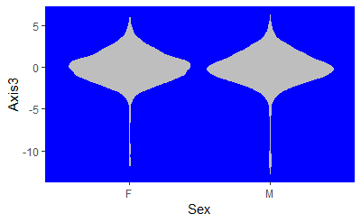

[figure not shown]

Now that we’ve examined the full dataset, let’s focus on only the hatchery origin fish to see if there is differentiation among the hatcheries.

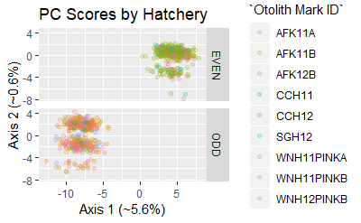

```r
par(mfrow=c(3,1))
Scores_Attributes %>%
  filter(`Otolith Mark Present`=="YES") %>%
  ggplot(aes(x=Axis1, y=Axis2, color=`Otolith Mark ID`)) +
  geom_point(alpha=0.2) +
  facet_grid(rows = vars(Lineage)) +
  labs(title="PC Scores by Hatchery", x="Axis 1 (~5.6%)", y="Axis 2 (~0.6%)")
```

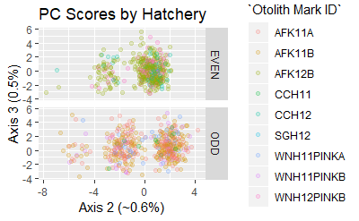

```r
Scores_Attributes %>%
  filter(`Otolith Mark Present`=="YES") %>%
  ggplot(aes(x=Axis2, y=Axis3, color=`Otolith Mark ID`)) +
  geom_point(alpha=0.2) +
  facet_grid(rows = vars(Lineage)) +
  labs(title="PC Scores by Hatchery", x="Axis 2 (~0.6%)", y="Axis 3 (0.5%)")
```

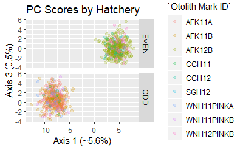

```r
Scores_Attributes %>%
  filter(`Otolith Mark Present`=="YES") %>%
  ggplot(aes(x=Axis1, y=Axis3, color=`Otolith Mark ID`)) +
  geom_point(alpha=0.2) +
  facet_grid(rows = vars(Lineage)) +
  labs(title="PC Scores by Hatchery", x="Axis 1 (~5.6%)", y="Axis 3 (0.5%)")
```

These are plots of only hatchery fish. We do see some clustering along axes 2 and 3, but particular hatcheries do not seem to be grouping together. Overall, hatchery fish appear to be mixed.

```r
aov_PC1_hatchery <- aov(Scores_Attributes$Axis1 ~ Scores_Attributes$`Otolith Mark ID`)
summary(aov_PC1_hatchery)
```

```
                                     Df Sum Sq Mean Sq F value Pr(>F)
Scores_Attributes$`Otolith Mark ID`   8  34642    4330    2655 <2e-16 ***
Residuals                           876   1429       2
---
Signif. codes:  0 ‘***’ 0.001 ‘**’ 0.01 ‘*’ 0.05 ‘.’ 0.1 ‘ ’ 1
6482 observations deleted due to missingness
```

```r
aov_PC2_hatchery <- aov(Scores_Attributes$Axis2 ~ Scores_Attributes$`Otolith Mark ID`)
summary(aov_PC2_hatchery)
```

```
                                     Df Sum Sq Mean Sq F value Pr(>F)
Scores_Attributes$`Otolith Mark ID`   8     19   2.327   0.583  0.792
Residuals                           876   3495   3.989
6482 observations deleted due to missingness
```

```r
aov_PC3_hatchery <- aov(Scores_Attributes$Axis3 ~ Scores_Attributes$`Otolith Mark ID`)
summary(aov_PC3_hatchery)
```

```
                                     Df Sum Sq Mean Sq F value  Pr(>F)
Scores_Attributes$`Otolith Mark ID`   8     67   8.375   3.232 0.00124 **
Residuals                           876   2270   2.591
---
Signif. codes:  0 ‘***’ 0.001 ‘**’ 0.01 ‘*’ 0.05 ‘.’ 0.1 ‘ ’ 1
6482 observations deleted due to missingness
```

There are significant differences in Axis 1 and 3 scores among the different hatcheries. However, this significance is confounded by year.

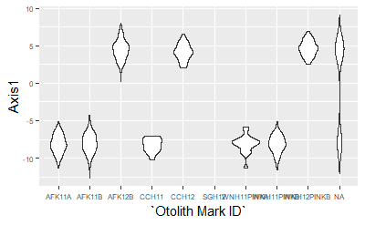

```r
#par(mfrow=c(3,1))
#boxplot(Scores_Attributes$Axis1~Scores_Attributes$`Otolith Mark ID`, ylab="PC 1 Scores", par(cex.axis=0.5))
#boxplot(Scores_Attributes$Axis2~Scores_Attributes$`Otolith Mark ID`, ylab="PC 2 Scores", par(cex.axis=0.5))
#boxplot(Scores_Attributes$Axis3~Scores_Attributes$`Otolith Mark ID`, ylab="PC 3 Scores", par(cex.axis=0.5))
ggplot(Scores_Attributes, aes(x=`Otolith Mark ID`, y=Axis1)) +
  geom_violin() +
  theme(axis.text=element_text(size=6))
```

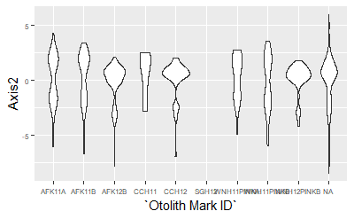

```r
ggplot(Scores_Attributes, aes(x=`Otolith Mark ID`, y=Axis2)) +
  geom_violin() +
  theme(axis.text=element_text(size=6))
```

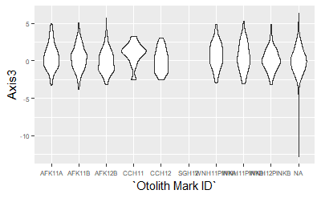

```r
ggplot(Scores_Attributes, aes(x=`Otolith Mark ID`, y=Axis3)) +
  geom_violin() +
  theme(axis.text=element_text(size=6))
```

We can visualize differences in Axis scores among hatcheries using violin plots. The strongest differentiation is seen in Axis 1, with hatcheries splitting by lineage. Distributions appear more similar in scores from axes 2 and 3. Note that NA denotes natural fish.

```r
Scores_Attributes %>%
  count(SILLY_CODE, `Otolith Mark ID`) %>%
  spread(`Otolith Mark ID`, n, fill=0)
```

| SILLY_CODE | AFK11A | AFK11B | AFK12B | CCH11 | CCH12 | SGH12 | WNH11PINKA | WNH11PINKB | WNH12PINKB | <NA> |
| --- | --- | --- | --- | --- | --- | --- | --- | --- | --- | --- |
| PHOGAN13 | 146 | 204 | 0 | 12 | 0 | 0 | 33 | 50 | 0 | 322 |
| PHOGAN14 | 0 | 0 | 306 | 0 | 49 | 1 | 0 | 0 | 84 | 214 |
| PHOGAN15 | 0 | 0 | 0 | 0 | 0 | 0 | 0 | 0 | 0 | 1920 |
| PHOGAN16 | 0 | 0 | 0 | 0 | 0 | 0 | 0 | 0 | 0 | 4026 |

Here are the counts of hatchery fish by year. Note that there is only 1 fish from Solomon Gulch, which explains the missing data in the plots above.

Since the PCA for the full dataset was so strongly driven by differences between lineages, we decided to perform separate PCA’s by lineage to better examine differentiation.

```r
#Replace missing data.
Hogan_imputed_odd <- scaleGen(Hogan_odd, NA.method="mean")
class(Hogan_imputed_odd)
```

```
[1] "matrix"
```

```r
dim(Hogan_imputed_odd)
```

```
[1] 2687  665
```

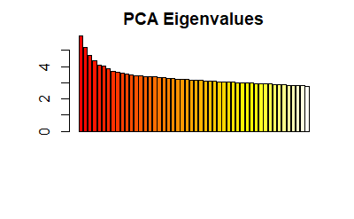

```r
pca_odd <- dudi.pca(Hogan_imputed_odd, cent=FALSE, scale=FALSE, scannf=FALSE, nf=3)
barplot(pca_odd$eig[1:50], main="PCA Eigenvalues", col=heat.colors(50))
```

```r
summary(pca_odd)
```

```
Class: pca dudi
Call: dudi.pca(df = Hogan_imputed_odd, center = FALSE, scale = FALSE,
    scannf = FALSE, nf = 3)

Total inertia: 664.8

Eigenvalues:
    Ax1     Ax2     Ax3     Ax4     Ax5
  5.914   5.208   4.719   4.342   4.118

Projected inertia (%):
    Ax1     Ax2     Ax3     Ax4     Ax5
 0.8896  0.7834  0.7100  0.6531  0.6195

Cumulative projected inertia (%):
    Ax1   Ax1:2   Ax1:3   Ax1:4   Ax1:5
 0.8896  1.6730  2.3830  3.0361  3.6556

(Only 5 dimensions (out of 361) are shown)
```

These are eigenvalues for a PCA that only includes odd-lineage fish. Note that the eigenvalues are much more similar.

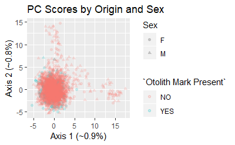

```r
Scores_Attributes_odd <- pca_odd$li %>%
  as_tibble(rownames="silly_source") %>%
  left_join(HOGAN_attributes_odd_tibble, by=c("silly_source"= "SillySource"))
ggplot(Scores_Attributes_odd, aes(x=Axis1, y=Axis2, color=`Otolith Mark Present`, shape=Sex)) +
  geom_point(alpha=0.2) +
  labs(title = "PC Scores by Origin and Sex", x="Axis 1 (~0.9%)", y="Axis 2 (~0.8%)")
```

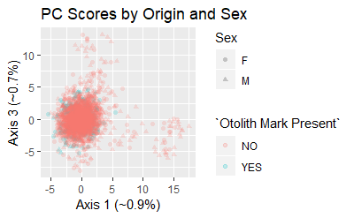

```r
ggplot(Scores_Attributes_odd, aes(x=Axis1, y=Axis3, color=`Otolith Mark Present`, shape=Sex)) +
  geom_point(alpha=0.2) +
  labs(title = "PC Scores by Origin and Sex", x="Axis 1 (~0.9%)", y="Axis 3 (~0.7%)")
```